# Overview:

**Currently, there are 5 types of packages the company is offering - Basic, Standard, Deluxe, Super Deluxe, King. Looking at the data of the last year, we observed that 18% of the customers purchased the packages. However, the marketing cost was quite high because customers were contacted at random without looking at the available information. The company is now planning to launch a new product i.e. Wellness Tourism Package. Wellness Tourism is defined as Travel that allows the traveler to maintain, enhance or kick-start a healthy lifestyle, and support or increase one's sense of well-being. However, this time company wants to harness the available data of existing and potential customers to make the marketing expenditure more efficient.Analyze the customers' data and information to provide recommendations to the Policy Maker and Marketing Team and also build a model to predict the potential customer who is going to purchase the newly introduced travel package.**

# Objective:

**To predict which customer is more likely to purchase the newly introduced travel package.**

# Data Description:

## Customer details:

1. CustomerID: Unique customer ID
2. ProdTaken: Whether the customer has purchased a package or not (0: No, 1: Yes)
3. Age: Age of customer
4. TypeofContact: How customer was contacted (Company Invited or Self Inquiry)
5. CityTier: City tier depends on the development of a city, population, facilities, and living standards. The categories are ordered i.e. Tier 1 > Tier 2 > Tier 3
6. Occupation: Occupation of customer
7. Gender: Gender of customer
8. NumberOfPersonVisiting: Total number of persons planning to take the trip with the customer
9. PreferredPropertyStar: Preferred hotel property rating by customer
10. MaritalStatus: Marital status of customer
11. NumberOfTrips: Average number of trips in a year by customer
12. Passport: The customer has a passport or not (0: No, 1: Yes)
13. OwnCar: Whether the customers own a car or not (0: No, 1: Yes)
14. NumberOfChildrenVisiting: Total number of children with age less than 5 planning to take the trip with the customer
15. Designation: Designation of the customer in the current organization
16. MonthlyIncome: Gross monthly income of the customer

## Customer interaction data:

1. PitchSatisfactionScore: Sales pitch satisfaction score
2. ProductPitched: Product pitched by the salesperson
3. NumberOfFollowups: Total number of follow-ups has been done by the salesperson after the sales pitch
4. DurationOfPitch: Duration of the pitch by a salesperson to the customer

### Import necesscary libraries

```python
import pandas as pd
import numpy as np
from sklearn import metrics
import matplotlib.pyplot as plt
%matplotlib inline
import seaborn as sns
import warnings
warnings.filterwarnings('ignore')


from sklearn.model_selection import train_test_split
from sklearn.model_selection import GridSearchCV
from sklearn.ensemble import BaggingClassifier, RandomForestClassifier
from sklearn.linear_model import LogisticRegression
from sklearn.ensemble import AdaBoostClassifier, GradientBoostingClassifier
from sklearn.ensemble import StackingClassifier
from sklearn.tree import DecisionTreeClassifier

# Libtune to tune model, get different metric scores
from sklearn import metrics
from sklearn.metrics import confusion_matrix, classification_report, accuracy_score, precision_score, recall_score
from sklearn.model_selection import GridSearchCV
```

```python
from xgboost import XGBClassifier
```

### Read the dataset

```python
data = pd.read_excel("Tourism.xlsx",sheet_name='Tourism', index_col = None)
```

```python
data.head()
```

|  | CustomerID | ProdTaken | Age | TypeofContact | CityTier | DurationOfPitch | Occupation | Gender | NumberOfPersonVisiting | NumberOfFollowups | ProductPitched | PreferredPropertyStar | MaritalStatus | NumberOfTrips | Passport | PitchSatisfactionScore | OwnCar | NumberOfChildrenVisiting | Designation | MonthlyIncome |
| --- | --- | --- | --- | --- | --- | --- | --- | --- | --- | --- | --- | --- | --- | --- | --- | --- | --- | --- | --- | --- |
| 0 | 200000 | 1 | 41.0 | Self Enquiry | 3 | 6.0 | Salaried | Female | 3 | 3.0 | Deluxe | 3.0 | Single | 1.0 | 1 | 2 | 1 | 0.0 | Manager | 20993.0 |
| 1 | 200001 | 0 | 49.0 | Company Invited | 1 | 14.0 | Salaried | Male | 3 | 4.0 | Deluxe | 4.0 | Divorced | 2.0 | 0 | 3 | 1 | 2.0 | Manager | 20130.0 |
| 2 | 200002 | 1 | 37.0 | Self Enquiry | 1 | 8.0 | Free Lancer | Male | 3 | 4.0 | Basic | 3.0 | Single | 7.0 | 1 | 3 | 0 | 0.0 | Executive | 17090.0 |
| 3 | 200003 | 0 | 33.0 | Company Invited | 1 | 9.0 | Salaried | Female | 2 | 3.0 | Basic | 3.0 | Divorced | 2.0 | 1 | 5 | 1 | 1.0 | Executive | 17909.0 |
| 4 | 200004 | 0 | NaN | Self Enquiry | 1 | 8.0 | Small Business | Male | 2 | 3.0 | Basic | 4.0 | Divorced | 1.0 | 0 | 5 | 1 | 0.0 | Executive | 18468.0 |

```python
data.drop('CustomerID', inplace = True, axis = 1)
```

```python
data.head()
```

|  | ProdTaken | Age | TypeofContact | CityTier | DurationOfPitch | Occupation | Gender | NumberOfPersonVisiting | NumberOfFollowups | ProductPitched | PreferredPropertyStar | MaritalStatus | NumberOfTrips | Passport | PitchSatisfactionScore | OwnCar | NumberOfChildrenVisiting | Designation | MonthlyIncome |
| --- | --- | --- | --- | --- | --- | --- | --- | --- | --- | --- | --- | --- | --- | --- | --- | --- | --- | --- | --- |
| 0 | 1 | 41.0 | Self Enquiry | 3 | 6.0 | Salaried | Female | 3 | 3.0 | Deluxe | 3.0 | Single | 1.0 | 1 | 2 | 1 | 0.0 | Manager | 20993.0 |
| 1 | 0 | 49.0 | Company Invited | 1 | 14.0 | Salaried | Male | 3 | 4.0 | Deluxe | 4.0 | Divorced | 2.0 | 0 | 3 | 1 | 2.0 | Manager | 20130.0 |
| 2 | 1 | 37.0 | Self Enquiry | 1 | 8.0 | Free Lancer | Male | 3 | 4.0 | Basic | 3.0 | Single | 7.0 | 1 | 3 | 0 | 0.0 | Executive | 17090.0 |
| 3 | 0 | 33.0 | Company Invited | 1 | 9.0 | Salaried | Female | 2 | 3.0 | Basic | 3.0 | Divorced | 2.0 | 1 | 5 | 1 | 1.0 | Executive | 17909.0 |
| 4 | 0 | NaN | Self Enquiry | 1 | 8.0 | Small Business | Male | 2 | 3.0 | Basic | 4.0 | Divorced | 1.0 | 0 | 5 | 1 | 0.0 | Executive | 18468.0 |

```python
data.shape #columns and rows
```

```
(4888, 19)
```

```python
data.info()
```

```
<class 'pandas.core.frame.DataFrame'>
RangeIndex: 4888 entries, 0 to 4887
Data columns (total 19 columns):
 #   Column                    Non-Null Count  Dtype
---  ------                    --------------  -----
 0   ProdTaken                 4888 non-null   int64
 1   Age                       4662 non-null   float64
 2   TypeofContact             4863 non-null   object
 3   CityTier                  4888 non-null   int64
 4   DurationOfPitch           4637 non-null   float64
 5   Occupation                4888 non-null   object
 6   Gender                    4888 non-null   object
 7   NumberOfPersonVisiting    4888 non-null   int64
 8   NumberOfFollowups         4843 non-null   float64
 9   ProductPitched            4888 non-null   object
 10  PreferredPropertyStar     4862 non-null   float64
 11  MaritalStatus             4888 non-null   object
 12  NumberOfTrips             4748 non-null   float64
 13  Passport                  4888 non-null   int64
 14  PitchSatisfactionScore    4888 non-null   int64
 15  OwnCar                    4888 non-null   int64
 16  NumberOfChildrenVisiting  4822 non-null   float64
 17  Designation               4888 non-null   object
 18  MonthlyIncome             4655 non-null   float64
dtypes: float64(7), int64(6), object(6)
memory usage: 725.7+ KB
```

Obseravtions:

1. A lot of the data set are of non-numeric type.
2. For EDA purposes the data set is fine to use
3. For modelling purposes the data set will have to be in int/float form.

```python
data.nunique()
```

```
ProdTaken                      2
Age                           44
TypeofContact                  2
CityTier                       3
DurationOfPitch               34
Occupation                     4
Gender                         3
NumberOfPersonVisiting         5
NumberOfFollowups              6
ProductPitched                 5
PreferredPropertyStar          3
MaritalStatus                  4
NumberOfTrips                 12
Passport                       2
PitchSatisfactionScore         5
OwnCar                         2
NumberOfChildrenVisiting       4
Designation                    5
MonthlyIncome               2475
dtype: int64
```

```python
replace = {'Gender': {'Fe Male': 'Female'}} #There are only two geneders mentioned in the variable set, trasfomrting Fe Male into Female category
data = data.replace(replace)
data.nunique()
```

```
ProdTaken                      2
Age                           44
TypeofContact                  2
CityTier                       3
DurationOfPitch               34
Occupation                     4
Gender                         2
NumberOfPersonVisiting         5
NumberOfFollowups              6
ProductPitched                 5
PreferredPropertyStar          3
MaritalStatus                  4
NumberOfTrips                 12
Passport                       2
PitchSatisfactionScore         5
OwnCar                         2
NumberOfChildrenVisiting       4
Designation                    5
MonthlyIncome               2475
dtype: int64
```

```python
data.isnull().sum().sort_values(ascending=False) #sum of all the null values per variable
```

```
DurationOfPitch             251
MonthlyIncome               233
Age                         226
NumberOfTrips               140
NumberOfChildrenVisiting     66
NumberOfFollowups            45
PreferredPropertyStar        26
TypeofContact                25
Gender                        0
CityTier                      0
Occupation                    0
ProductPitched                0
NumberOfPersonVisiting        0
Designation                   0
MaritalStatus                 0
Passport                      0
PitchSatisfactionScore        0
OwnCar                        0
ProdTaken                     0
dtype: int64
```

Observations:

1. There are significant number of null values missing in 8 of the variables.
2. Since most of the variables are of categorical type they can be categorized 'as_missing'
3. Rest of the missing values can be imputed with median

```python
category = ['ProdTaken','TypeofContact','CityTier','Occupation', 'Gender','NumberOfPersonVisiting','NumberOfFollowups', 'ProductPitched','PreferredPropertyStar', 'MaritalStatus','NumberOfTrips','Passport','PitchSatisfactionScore','OwnCar','NumberOfChildrenVisiting', 'Designation']
print(len(category))
for i in category:
   data[i] = data[i].astype('category')
```

```
16
```

```python
data.info()
```

```
<class 'pandas.core.frame.DataFrame'>
RangeIndex: 4888 entries, 0 to 4887
Data columns (total 19 columns):
 #   Column                    Non-Null Count  Dtype
---  ------                    --------------  -----
 0   ProdTaken                 4888 non-null   category
 1   Age                       4662 non-null   float64
 2   TypeofContact             4863 non-null   category
 3   CityTier                  4888 non-null   category
 4   DurationOfPitch           4637 non-null   float64
 5   Occupation                4888 non-null   category
 6   Gender                    4888 non-null   category
 7   NumberOfPersonVisiting    4888 non-null   category
 8   NumberOfFollowups         4843 non-null   category
 9   ProductPitched            4888 non-null   category
 10  PreferredPropertyStar     4862 non-null   category
 11  MaritalStatus             4888 non-null   category
 12  NumberOfTrips             4748 non-null   category
 13  Passport                  4888 non-null   category
 14  PitchSatisfactionScore    4888 non-null   category
 15  OwnCar                    4888 non-null   category
 16  NumberOfChildrenVisiting  4822 non-null   category
 17  Designation               4888 non-null   category
 18  MonthlyIncome             4655 non-null   float64
dtypes: category(16), float64(3)
memory usage: 193.7 KB
```

```python
median_imputation_values = ['DurationOfPitch', 'MonthlyIncome','Age' ]
for i in median_imputation_values: #converting missing values with median
    data[i].fillna(data[i].median(), inplace=True)
```

```python
data['TypeofContact'] = data['TypeofContact'].astype(str).replace('nan', 'is_missing').astype('category') #converting categoical missing values
data['NumberOfFollowups'] = data['NumberOfFollowups'].astype(str).replace('nan', 'is_missing').astype('category')
data['PreferredPropertyStar'] = data['PreferredPropertyStar'].astype(str).replace('nan', 'is_missing').astype('category')
data['NumberOfChildrenVisiting'] = data['NumberOfChildrenVisiting'].astype(str).replace('nan', 'is_missing').astype('category')
data['NumberOfTrips'] = data['NumberOfTrips'].astype(str).replace('nan', 'is_missing').astype('category')
```

```python
data.isnull().sum().sort_values(ascending = False) #sum of all null values
```

```
MonthlyIncome               0
NumberOfFollowups           0
Age                         0
TypeofContact               0
CityTier                    0
DurationOfPitch             0
Occupation                  0
Gender                      0
NumberOfPersonVisiting      0
ProductPitched              0
Designation                 0
PreferredPropertyStar       0
MaritalStatus               0
NumberOfTrips               0
Passport                    0
PitchSatisfactionScore      0
OwnCar                      0
NumberOfChildrenVisiting    0
ProdTaken                   0
dtype: int64
```

```python
data.info()
```

```
<class 'pandas.core.frame.DataFrame'>
RangeIndex: 4888 entries, 0 to 4887
Data columns (total 19 columns):
 #   Column                    Non-Null Count  Dtype
---  ------                    --------------  -----
 0   ProdTaken                 4888 non-null   category
 1   Age                       4888 non-null   float64
 2   TypeofContact             4888 non-null   category
 3   CityTier                  4888 non-null   category
 4   DurationOfPitch           4888 non-null   float64
 5   Occupation                4888 non-null   category
 6   Gender                    4888 non-null   category
 7   NumberOfPersonVisiting    4888 non-null   category
 8   NumberOfFollowups         4888 non-null   category
 9   ProductPitched            4888 non-null   category
 10  PreferredPropertyStar     4888 non-null   category
 11  MaritalStatus             4888 non-null   category
 12  NumberOfTrips             4888 non-null   category
 13  Passport                  4888 non-null   category
 14  PitchSatisfactionScore    4888 non-null   category
 15  OwnCar                    4888 non-null   category
 16  NumberOfChildrenVisiting  4888 non-null   category
 17  Designation               4888 non-null   category
 18  MonthlyIncome             4888 non-null   float64
dtypes: category(16), float64(3)
memory usage: 194.3 KB
```

```python
continous_columns = ['Age','DurationOfPitch', 'MonthlyIncome']
```

```python
data.describe().T
```

|  | count | mean | std | min | 25% | 50% | 75% | max |
| --- | --- | --- | --- | --- | --- | --- | --- | --- |
| Age | 4888.0 | 37.547259 | 9.104795 | 18.0 | 31.0 | 36.0 | 43.00 | 61.0 |
| DurationOfPitch | 4888.0 | 15.362930 | 8.316166 | 5.0 | 9.0 | 13.0 | 19.00 | 127.0 |
| MonthlyIncome | 4888.0 | 23559.179419 | 5257.862921 | 1000.0 | 20485.0 | 22347.0 | 25424.75 | 98678.0 |

```python
data.describe(include = 'category').T
```

|  | count | unique | top | freq |
| --- | --- | --- | --- | --- |
| ProdTaken | 4888 | 2 | 0 | 3968 |
| TypeofContact | 4888 | 3 | Self Enquiry | 3444 |
| CityTier | 4888 | 3 | 1 | 3190 |
| Occupation | 4888 | 4 | Salaried | 2368 |
| Gender | 4888 | 2 | Male | 2916 |
| NumberOfPersonVisiting | 4888 | 5 | 3 | 2402 |
| NumberOfFollowups | 4888 | 7 | 4.0 | 2068 |
| ProductPitched | 4888 | 5 | Basic | 1842 |
| PreferredPropertyStar | 4888 | 4 | 3.0 | 2993 |
| MaritalStatus | 4888 | 4 | Married | 2340 |
| NumberOfTrips | 4888 | 13 | 2.0 | 1464 |
| Passport | 4888 | 2 | 0 | 3466 |
| PitchSatisfactionScore | 4888 | 5 | 3 | 1478 |
| OwnCar | 4888 | 2 | 1 | 3032 |
| NumberOfChildrenVisiting | 4888 | 5 | 1.0 | 2080 |
| Designation | 4888 | 5 | Executive | 1842 |

Observations on the data set:

# EDA

```python
def histogram_boxplot(feature):
    """ Boxplot and histogram combined
    feature: 1-d feature array
    """
    figure, (ax_box2, ax_hist2, ax_hist3) = plt.subplots(
        nrows = 1, ncols=3,# Number of rows of the subplot grid= 2
        figsize  = (20,5)) # creating the 2 subplots
    figure.tight_layout(pad = 7)
    sns.boxplot(x = feature,ax=ax_box2, color = '#4B8BBE', orient = 'v') # boxplot will be created
    sns.distplot(feature, kde=True, ax=ax_hist2, color = '#a9a38f') # For histogram
    sns.distplot(feature, kde= True, ax=ax_hist3, hist = False) #Making an outline of the histogram
    ax_hist2.axvline(np.mean(feature), color='r', linestyle='--') # Add mean to the histogram
    ax_hist2.axvline(np.median(feature), color='black', linestyle='-') # Add median to the histogram
    ax_hist3.axvline(np.mean(feature), color = 'black', linestyle = '--') #Adding mean to second histogram
    ax_hist3.axvline(np.median(feature), color='black', linestyle='-') #Adding median to second histogram
```

## Univariate Analysis

### Observations of Age

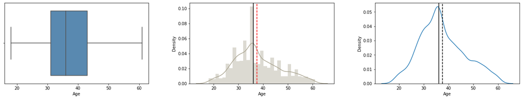

```python
histogram_boxplot(data[continous_columns[0]])
```

Observations:

1. The variable does not have any outliers
2. Pretty overal balanced data
3. The max age is around 61 years old.

### Observations on Duration of Pitch

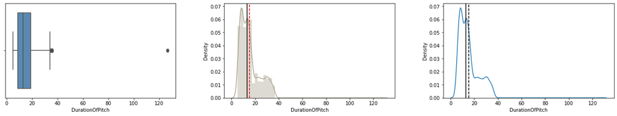

```python
histogram_boxplot(data[continous_columns[1]])
```

Observations:

1. There appear to be 2 outliers on the highersidde
2. The graph is pretty right-scaled
3. Log transformation may be applied to DUration of Pitch

### Observations on Monlthy Income

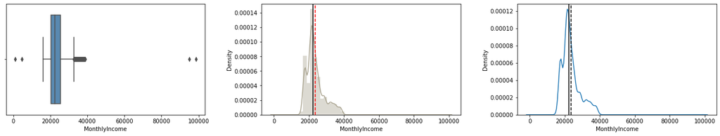

```python
histogram_boxplot(data[continous_columns[2]])
```

Observations:

1. A lot of outliers are visible.
2. The graph is right-skewed
3. Log transformation may be applied to monlthy income as well.

## Outlier treatments

```python
# Let's treat outliers by flooring and capping
def treat_outliers(df, col):
    """
    treats outliers in a variable
    col: str, name of the numerical variable
    df: dataframe
    col: name of the column
    """
    Q1 = df[col].quantile(0.25)  # 25th quantile
    Q3 = df[col].quantile(0.75)  # 75th quantile
    IQR = Q3 - Q1
    Lower_Whisker = Q1 - 1.5 * IQR
    Upper_Whisker = Q3 + 1.5 * IQR

    # all the values smaller than Lower_Whisker will be assigned the value of Lower_Whisker
    # all the values greater than Upper_Whisker will be assigned the value of Upper_Whisker
    df[col] = np.clip(df[col], Lower_Whisker, Upper_Whisker)

    return df


def treat_outliers_all(df, col_list):
    """
    treat outlier in all numerical variables
    col_list: list of numerical variables
    df: data frame
    """
    for c in col_list:
        df = treat_outliers(df, c)

    return df
```

```python
numerical_col = data.select_dtypes(include=np.number).columns.tolist()#converting numerical cols
data = treat_outliers_all(data, numerical_col) #treating outliers
```

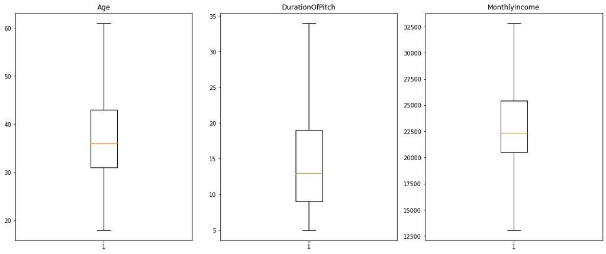

```python
plt.figure(figsize=(20, 30))

for i, variable in enumerate(numerical_col): #boxplots subplots
    plt.subplot(5, 4, i + 1)
    plt.boxplot(data[variable], whis=1.5)
    plt.tight_layout()
    plt.title(variable)

plt.show()
```

Observations:

1. No visible outliers after the outlier treatment
2. Outlier treatment applied on the continous Variables Age, Duration of Pitch adn Monthly Income

## Categorical Variables

```python
def bar_perc(plot, feature):
    '''
    plot
    feature: 1-d categorical feature array
    '''
    total = len(feature) # length of the column
    for p in ax.patches:
        percentage = '{:.1f}%'.format(100 * p.get_height()/total) # percentage of each class of the category
        x = p.get_x() + p.get_width() / 2 - 0.05 # width of the plot
        y = p.get_y() + p.get_height()           # hieght of the plot
        ax.annotate(percentage, (x, y), size = 12) # annotate the percantage
```

### Observation on ProdTaken

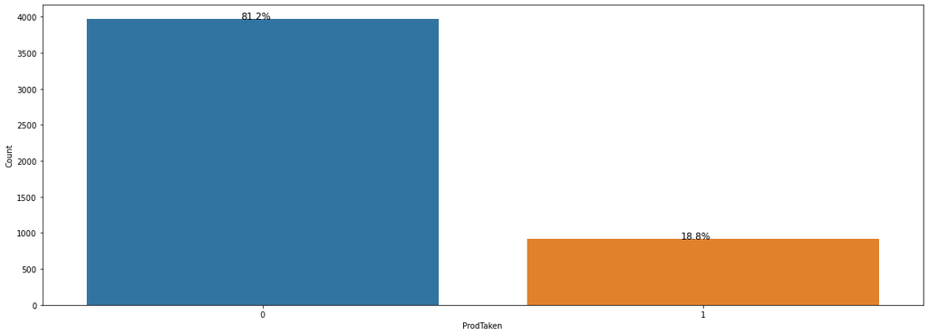

```python
plt.figure(figsize=(20,7))
ax = sns.countplot(data[category[0]]) #count plot for Name
plt.xlabel(category[0])
plt.ylabel('Count')
bar_perc(ax,data[category[0]])
```

Observation:

1. 18.8% of clients did take the product 2.81.2 % of the clients did not take the product.

### Observation Type Of Contact

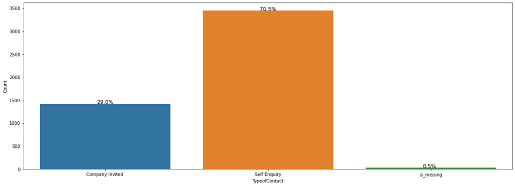

```python
plt.figure(figsize=(20,7))
ax = sns.countplot(data[category[1]]) #count plot for Name
plt.xlabel(category[1])
plt.ylabel('Count')
bar_perc(ax,data[category[1]])
```

Observations:

1. Self-enquiry are 70.5% of the clients
2. 29.0% are company invited clients

### Observation on CityTier

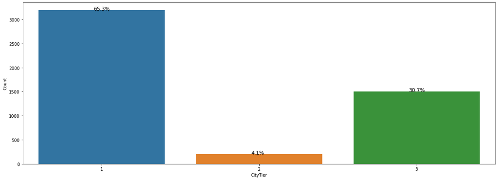

```python
plt.figure(figsize=(20,7))
ax = sns.countplot(data[category[2]]) #count plot for Name
plt.xlabel(category[2])
plt.ylabel('Count')
bar_perc(ax,data[category[2]])
```

Observations:

1. City tier 1 are 65.3%
2. City Tier 2 is 4.15%
3. City tier 3 is 30.7%

### Observation on Ocupation

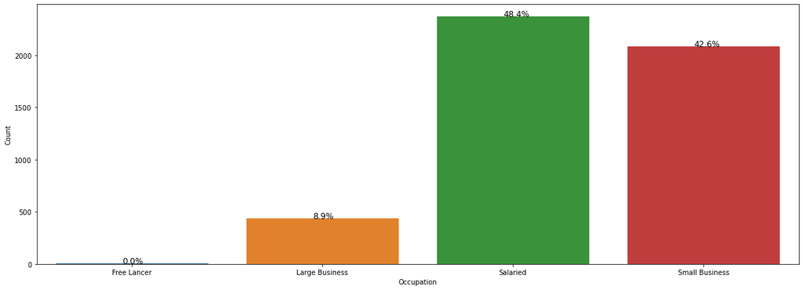

```python
plt.figure(figsize=(20,7))
ax = sns.countplot(data[category[3]]) #count plot for Name
plt.xlabel(category[3])
plt.ylabel('Count')
bar_perc(ax,data[category[3]])
```

Observations:

1. Ocupation of clients about 48.4% are Salaried
2. Large business are about 8.9% clients
3. Small business are about 42.6%

### Observation on Gender

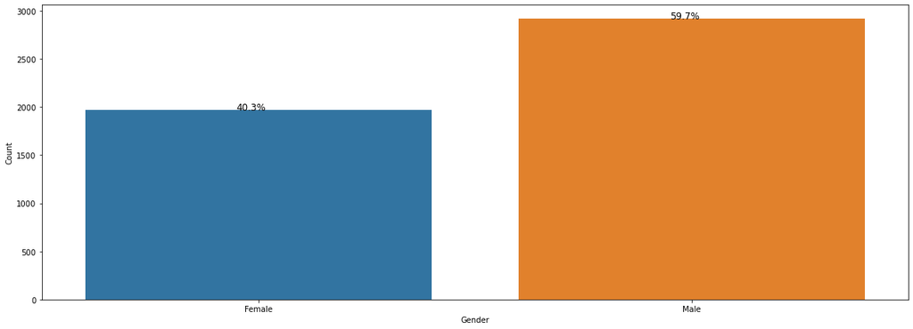

```python
plt.figure(figsize=(20,7))
ax = sns.countplot(data[category[4]]) #count plot for Name
plt.xlabel(category[4])
plt.ylabel('Count')
bar_perc(ax,data[category[4]])
```

Observations:

1. 40.3% of clients are female
2. 59.7% of the clients are male.

### Observation on Number of Person Visiting

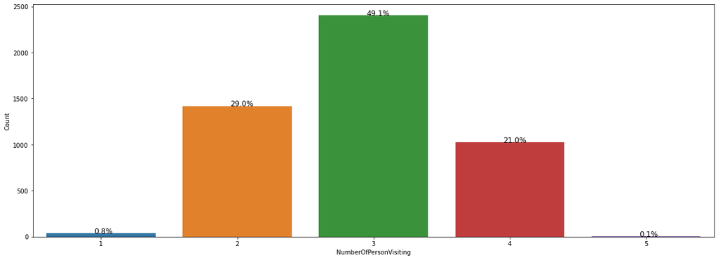

```python
plt.figure(figsize=(20,7))
ax = sns.countplot(data[category[5]]) #count plot for Name
plt.xlabel(category[5])
plt.ylabel('Count')
bar_perc(ax,data[category[5]])
```

Observations:

1. Highest Number of persons visitng are 3 with 49.1%
2. Lowest number of persons visitng are 5 followed by 1 with 0.1% and 0.8% respectively

### Observations on Number of Followups

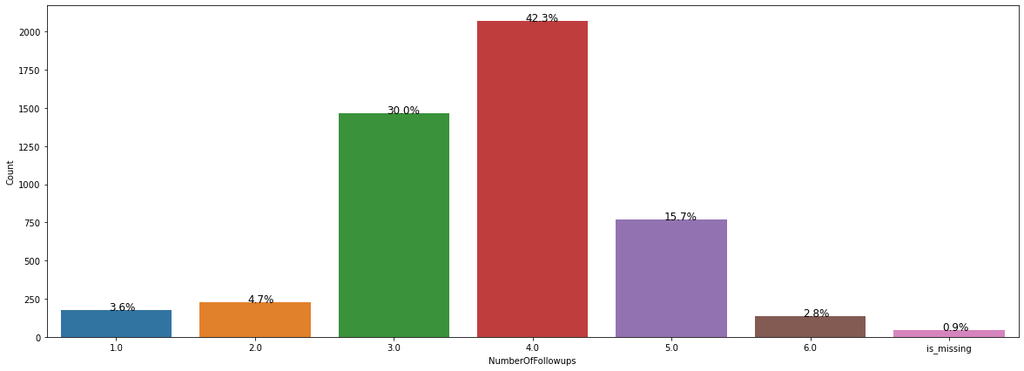

```python
plt.figure(figsize=(20,7))
ax = sns.countplot(data[category[6]]) #count plot for Name
plt.xlabel(category[6])
plt.ylabel('Count')
bar_perc(ax,data[category[6]])
```

Observations:

### Observations on Product Pitched

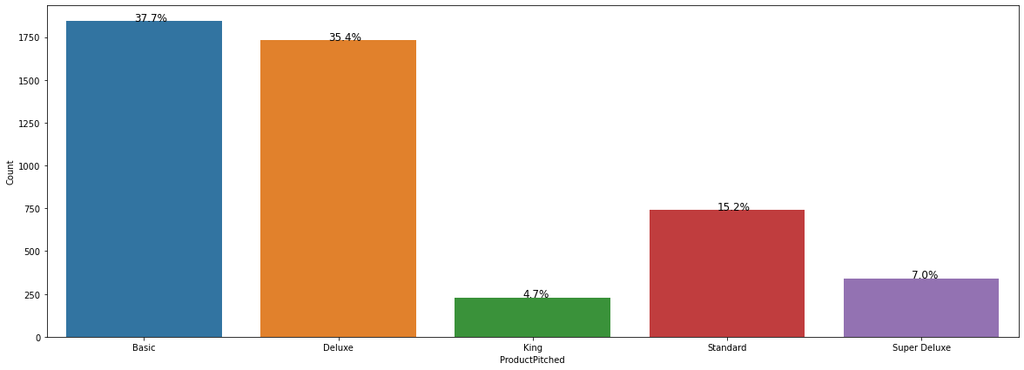

```python
plt.figure(figsize=(20,7))
ax = sns.countplot(data[category[7]]) #count plot for Name
plt.xlabel(category[7])
plt.ylabel('Count')
bar_perc(ax,data[category[7]])
```

Observations:

1. Most type of product pitched are basic and deluxe, with 37.7% and 35.4% respectively.
2. Least type of product pitched is the king and super deluxe with 4.7% and 7%.

### Observations on Preffered Property Star

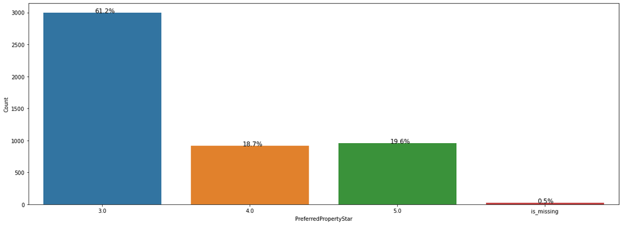

```python
plt.figure(figsize=(20,7))
ax = sns.countplot(data[category[8]]) #count plot for Name
plt.xlabel(category[8])
plt.ylabel('Count')
bar_perc(ax,data[category[8]])
```

Observations:

### Observations on Martial Status

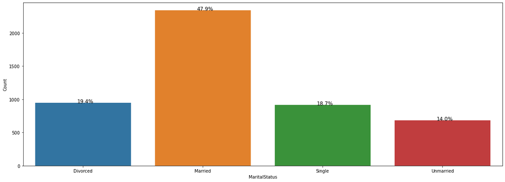

```python
plt.figure(figsize=(20,7))
ax = sns.countplot(data[category[9]]) #count plot for Name
plt.xlabel(category[9])
plt.ylabel('Count')
bar_perc(ax,data[category[9]])
```

Observations:

### Observations on Number of trips

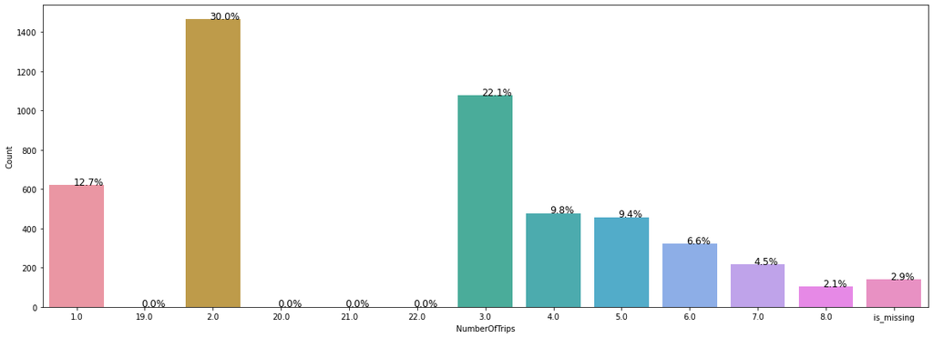

```python
plt.figure(figsize=(20,7))
ax = sns.countplot(data[category[10]]) #count plot for Name
plt.xlabel(category[10])
plt.ylabel('Count')
bar_perc(ax,data[category[10]])
```

Observations:

### Observations on Passport avaiablity

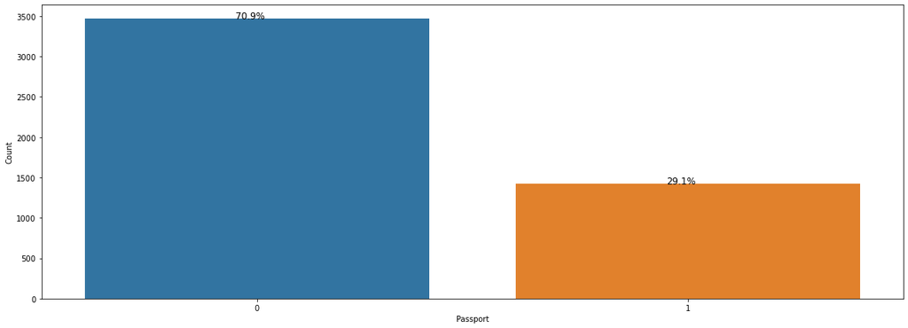

```python
plt.figure(figsize=(20,7))
ax = sns.countplot(data[category[11]]) #count plot for Name
plt.xlabel(category[11])
plt.ylabel('Count')
bar_perc(ax,data[category[11]])
```

Observations:

1. 70.9% of the clients do not own passports
2. Only 29.1% of the clients own passports

### Observation on Pitch satisfactory score

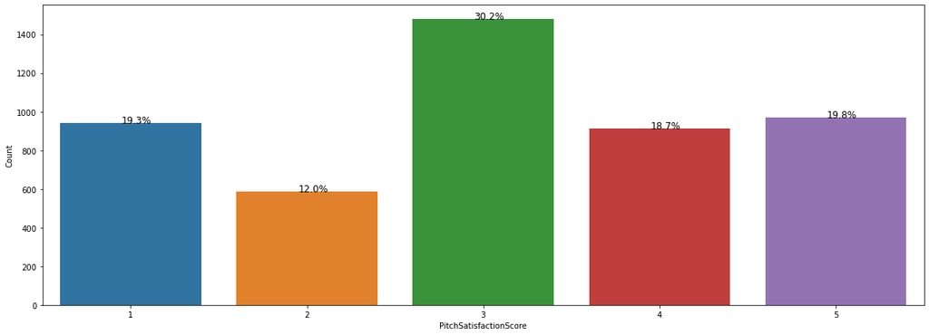

```python
plt.figure(figsize=(20,7))
ax = sns.countplot(data[category[12]]) #count plot for Name
plt.xlabel(category[12])
plt.ylabel('Count')
bar_perc(ax,data[category[12]])
```

Observations:

1. Highest pitch satisfactory score is 3 with 30.2%
2. Lowest ptich satisfactory score is 2 with 12%

### Observation on Owned car

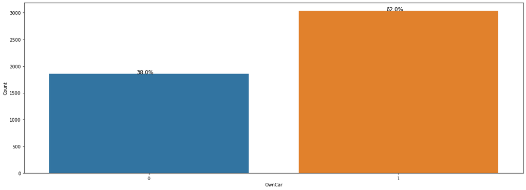

```python
plt.figure(figsize=(20,7))
ax = sns.countplot(data[category[13]]) #count plot for Name
plt.xlabel(category[13])
plt.ylabel('Count')
bar_perc(ax,data[category[13]])
```

Observations:

1. 38% of the clients do not own a car
2. 62% of the cleints do own a car

### Observations on Number of children visting

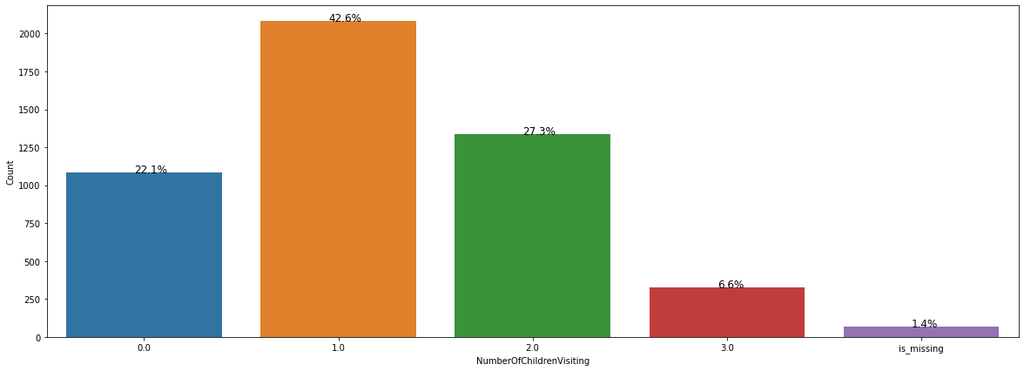

```python
plt.figure(figsize=(20,7))
ax = sns.countplot(data[category[14]]) #count plot for Name
plt.xlabel(category[14])
plt.ylabel('Count')
bar_perc(ax,data[category[14]])
```

Observations:

1. Lowest number of children visitng are 3 with 6.6%
2. Highest nunmber of children visiting are 1 with 42.6%

### Observations on Designation

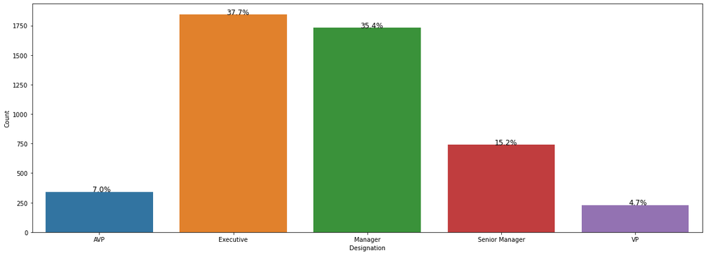

```python
plt.figure(figsize=(20,7))
ax = sns.countplot(data[category[15]]) #count plot for Name
plt.xlabel(category[15])
plt.ylabel('Count')
bar_perc(ax,data[category[15]])
```

Observations:

1. The least type of clients are VP with 4.7%
2. While the most common type of clients are executives and managers with 37.7% AND 35.4% respectively.

## Bivariate Analysis

```python
data.corr()
```

|  | Age | DurationOfPitch | MonthlyIncome |
| --- | --- | --- | --- |
| Age | 1.000000 | -0.011045 | 0.480201 |
| DurationOfPitch | -0.011045 | 1.000000 | 0.018051 |
| MonthlyIncome | 0.480201 | 0.018051 | 1.000000 |

```python
data.cov()
```

|  | Age | DurationOfPitch | MonthlyIncome |
| --- | --- | --- | --- |
| Age | 82.897296 | -0.798305 | 1.973554e+04 |
| DurationOfPitch | -0.798305 | 63.016926 | 6.468061e+02 |
| MonthlyIncome | 19735.539424 | 646.806059 | 2.037568e+07 |

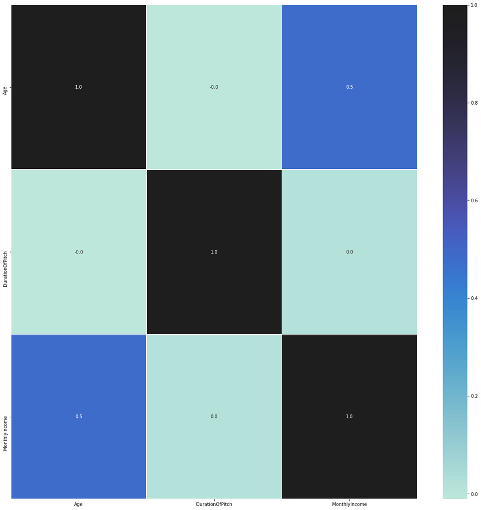

```python
plt.figure(figsize=(20,20))
sns.heatmap(data.corr(), annot=True, linewidths=.5, fmt= '.1f', center = 1 )  # heatmap
plt.show()
```

Observations:

1. Age and income show some correlation between each other but nothing too strong.
2. None of the variables really correlate well with each other

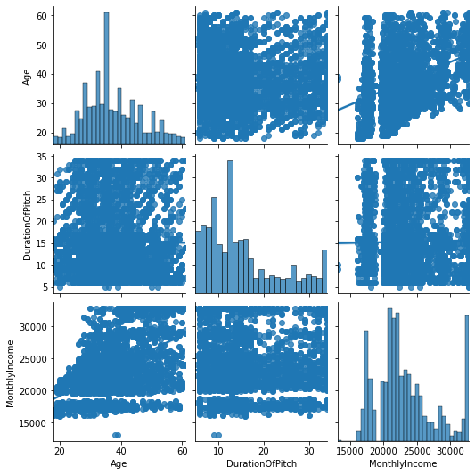

```python
plt.figure(figsize = (20,20))
sns.pairplot(data = data[numerical_col], kind = 'reg') #pairplot
plt.show()
```

Observations:

1. As indicated in the correlation table and the heatmap, there seems to be no strong correlation between any variables
2. No trend can be identified from the scatter plots as there is no correlation between the variables

### Product taken vs Continous Variables ( Age, Duration of Pitch and Monthly Income)

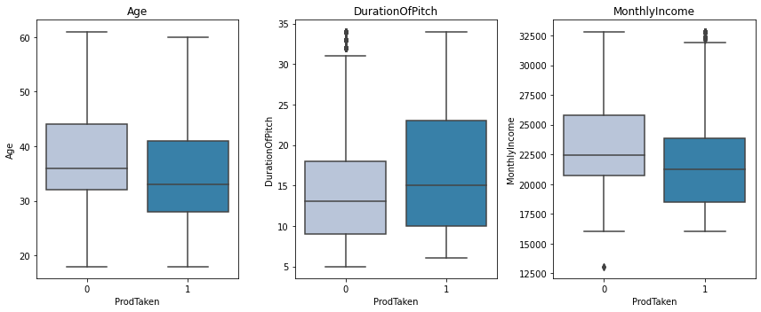

```python
cols = data[['Age', 'DurationOfPitch', 'MonthlyIncome']].columns.tolist()
plt.figure(figsize=(12,5))

for i, variable in enumerate(cols):
                     plt.subplot(1,3,i+1)
                     sns.boxplot(data['ProdTaken'],data[variable],palette="PuBu")
                     plt.tight_layout()
                     plt.title(variable)
plt.show()
```

Observations:

1. The average age for the clients that did not take the product are higher than the clients that did take the product.
2. The average of the duration of pitch is higher for the clients that did take the product.
3. The average for the montly income is slightly hgiher for clients that did not take the product.
4. There appear to be some outliers withthin the duration of pitch and monthyly income clients in product not taken and product taken respectively.

## Important Categorical variables vs Product Taken and Age

### Type of Contact vs Age vs Product Taken

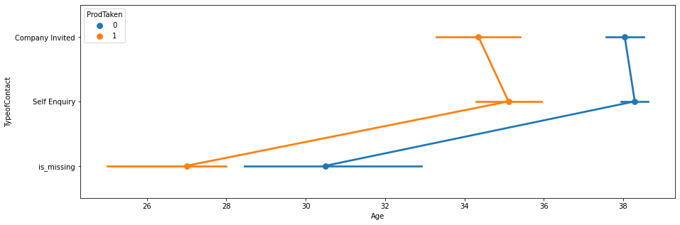

```python
plt.figure(figsize=(15,5))

sns.pointplot(x="Age", y="TypeofContact", hue = 'ProdTaken',  data=data)
plt.show()
```

Observation:

1. On average higher age clients did not take the product, for any type of contact.
2. In each category of type of cotanct higher age clients chose not to take the product.

### Gender vs Age vs Product Taken

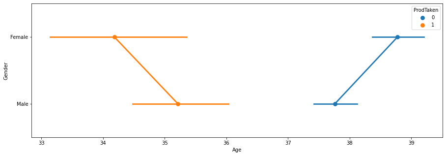

```python
plt.figure(figsize=(15,5))

sns.pointplot(x="Age", y="Gender", hue = 'ProdTaken',  data=data)
plt.show()
```

### Observation:

1. On average higher aged cleints both male and female opt to not take the product.

### Marital Status vs Age vs Product Taken

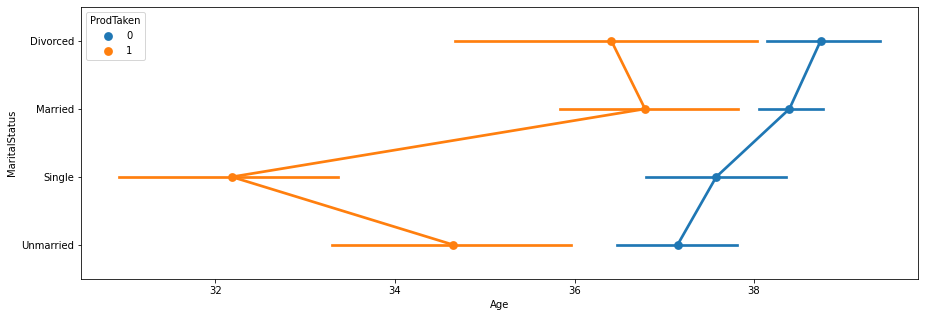

```python
plt.figure(figsize=(15,5))

sns.pointplot(x="Age", y="MaritalStatus", hue = 'ProdTaken',  data=data)
plt.show()
```

### Observation:

1. On Average higher aged individuals of all marital status did not take the product.

### Passport vs Age vs Product Taken

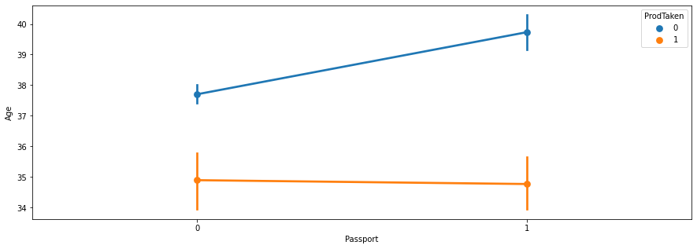

```python
plt.figure(figsize=(15,5))

sns.pointplot(x="Passport", y="Age", hue = 'ProdTaken',  data=data)
plt.show()
```

### Observations:

```python
data.to_csv('new_data.csv', index = False)
```

# Data Preparation For Modelling

```python
new_data = pd.read_csv('new_data.csv')
```

```python
new_data.head()
```

|  | ProdTaken | Age | TypeofContact | CityTier | DurationOfPitch | Occupation | Gender | NumberOfPersonVisiting | NumberOfFollowups | ProductPitched | PreferredPropertyStar | MaritalStatus | NumberOfTrips | Passport | PitchSatisfactionScore | OwnCar | NumberOfChildrenVisiting | Designation | MonthlyIncome |
| --- | --- | --- | --- | --- | --- | --- | --- | --- | --- | --- | --- | --- | --- | --- | --- | --- | --- | --- | --- |
| 0 | 1 | 41.0 | Self Enquiry | 3 | 6.0 | Salaried | Female | 3 | 3.0 | Deluxe | 3.0 | Single | 1.0 | 1 | 2 | 1 | 0.0 | Manager | 20993.0 |
| 1 | 0 | 49.0 | Company Invited | 1 | 14.0 | Salaried | Male | 3 | 4.0 | Deluxe | 4.0 | Divorced | 2.0 | 0 | 3 | 1 | 2.0 | Manager | 20130.0 |
| 2 | 1 | 37.0 | Self Enquiry | 1 | 8.0 | Free Lancer | Male | 3 | 4.0 | Basic | 3.0 | Single | 7.0 | 1 | 3 | 0 | 0.0 | Executive | 17090.0 |
| 3 | 0 | 33.0 | Company Invited | 1 | 9.0 | Salaried | Female | 2 | 3.0 | Basic | 3.0 | Divorced | 2.0 | 1 | 5 | 1 | 1.0 | Executive | 17909.0 |
| 4 | 0 | 36.0 | Self Enquiry | 1 | 8.0 | Small Business | Male | 2 | 3.0 | Basic | 4.0 | Divorced | 1.0 | 0 | 5 | 1 | 0.0 | Executive | 18468.0 |

```python
new_data.info()
```

```
<class 'pandas.core.frame.DataFrame'>
RangeIndex: 4888 entries, 0 to 4887
Data columns (total 19 columns):
 #   Column                    Non-Null Count  Dtype
---  ------                    --------------  -----
 0   ProdTaken                 4888 non-null   int64
 1   Age                       4888 non-null   float64
 2   TypeofContact             4888 non-null   object
 3   CityTier                  4888 non-null   int64
 4   DurationOfPitch           4888 non-null   float64
 5   Occupation                4888 non-null   object
 6   Gender                    4888 non-null   object
 7   NumberOfPersonVisiting    4888 non-null   int64
 8   NumberOfFollowups         4888 non-null   object
 9   ProductPitched            4888 non-null   object
 10  PreferredPropertyStar     4888 non-null   object
 11  MaritalStatus             4888 non-null   object
 12  NumberOfTrips             4888 non-null   object
 13  Passport                  4888 non-null   int64
 14  PitchSatisfactionScore    4888 non-null   int64
 15  OwnCar                    4888 non-null   int64
 16  NumberOfChildrenVisiting  4888 non-null   object
 17  Designation               4888 non-null   object
 18  MonthlyIncome             4888 non-null   float64
dtypes: float64(3), int64(6), object(10)
memory usage: 725.7+ KB
```

```python
print(new_data['TypeofContact'].value_counts())
print('*******************************************************')
print(new_data['Occupation'].value_counts())
print('*******************************************************')
print(new_data['Gender'].value_counts())
print('*******************************************************')
print(new_data['ProductPitched'].value_counts())
print('*******************************************************')
print(new_data['MaritalStatus'].value_counts())
print('*******************************************************')
print(new_data['Designation'].value_counts())
print('*******************************************************')
```

```
Self Enquiry       3444
Company Invited    1419
is_missing           25
Name: TypeofContact, dtype: int64
Salaried          2368
Small Business    2084
Large Business     434
Free Lancer          2
Name: Occupation, dtype: int64
Male      2916
Female    1972
Name: Gender, dtype: int64
Basic           1842
Deluxe          1732
Standard         742
Super Deluxe     342
King             230
Name: ProductPitched, dtype: int64
Married      2340
Divorced      950
Single        916
Unmarried     682
Name: MaritalStatus, dtype: int64
Executive         1842
Manager           1732
Senior Manager     742
AVP                342
VP                 230
Name: Designation, dtype: int64
```

```python
replaceStruct = {
                "TypeofContact": {"Self Enquiry": 1, "Company Invited": 2 ,"is_missing": -1},
                "Occupation": {"Salaried": 1, "Small Business":2 , "Large Business": 3, "Free Lancer": 4},
                 "Gender": {"Male": 1, "Female":2},
                 "ProductPitched": {"Basic": 1, "Standard": 2 ,"Deluxe": 3 ,"Super Deluxe": 4 ,"King": 5},
                "MaritalStatus": {"Unmarried": 1, "Single": 2, "Married":3, "Divorced":4 },
                "Designation": {"Executive": 1, "Manager": 2 ,"Senior Manager": 3 ,"AVP": 4 ,"VP": 5}
                    }
oneHotCols=["NumberOfPersonVisiting","NumberOfFollowups",'PreferredPropertyStar', 'NumberOfTrips','PitchSatisfactionScore','OwnCar','NumberOfChildrenVisiting', 'CityTier', 'Passport', 'TypeofContact','Occupation','Gender', 'ProductPitched', 'MaritalStatus','Designation']
```

```python
new_data = new_data.replace(replaceStruct)#replacing all the string columns with the integer associates
new_data = pd.get_dummies(new_data, columns=oneHotCols) #one code encoding
```

```python
new_data.head()
```

|  | ProdTaken | Age | DurationOfPitch | MonthlyIncome | NumberOfPersonVisiting_1 | NumberOfPersonVisiting_2 | NumberOfPersonVisiting_3 | NumberOfPersonVisiting_4 | NumberOfPersonVisiting_5 | NumberOfFollowups_1.0 | ... | ProductPitched_5 | MaritalStatus_1 | MaritalStatus_2 | MaritalStatus_3 | MaritalStatus_4 | Designation_1 | Designation_2 | Designation_3 | Designation_4 | Designation_5 |
| --- | --- | --- | --- | --- | --- | --- | --- | --- | --- | --- | --- | --- | --- | --- | --- | --- | --- | --- | --- | --- | --- |
| 0 | 1 | 41.0 | 6.0 | 20993.0 | 0 | 0 | 1 | 0 | 0 | 0 | ... | 0 | 0 | 1 | 0 | 0 | 0 | 1 | 0 | 0 | 0 |
| 1 | 0 | 49.0 | 14.0 | 20130.0 | 0 | 0 | 1 | 0 | 0 | 0 | ... | 0 | 0 | 0 | 0 | 1 | 0 | 1 | 0 | 0 | 0 |
| 2 | 1 | 37.0 | 8.0 | 17090.0 | 0 | 0 | 1 | 0 | 0 | 0 | ... | 0 | 0 | 1 | 0 | 0 | 1 | 0 | 0 | 0 | 0 |
| 3 | 0 | 33.0 | 9.0 | 17909.0 | 0 | 1 | 0 | 0 | 0 | 0 | ... | 0 | 0 | 0 | 0 | 1 | 1 | 0 | 0 | 0 | 0 |
| 4 | 0 | 36.0 | 8.0 | 18468.0 | 0 | 1 | 0 | 0 | 0 | 0 | ... | 0 | 0 | 0 | 0 | 1 | 1 | 0 | 0 | 0 | 0 |

5 rows × 73 columns

```python
new_data.info()
```

```
<class 'pandas.core.frame.DataFrame'>
RangeIndex: 4888 entries, 0 to 4887
Data columns (total 73 columns):
 #   Column                               Non-Null Count  Dtype
---  ------                               --------------  -----
 0   ProdTaken                            4888 non-null   int64
 1   Age                                  4888 non-null   float64
 2   DurationOfPitch                      4888 non-null   float64
 3   MonthlyIncome                        4888 non-null   float64
 4   NumberOfPersonVisiting_1             4888 non-null   uint8
 5   NumberOfPersonVisiting_2             4888 non-null   uint8
 6   NumberOfPersonVisiting_3             4888 non-null   uint8
 7   NumberOfPersonVisiting_4             4888 non-null   uint8
 8   NumberOfPersonVisiting_5             4888 non-null   uint8
 9   NumberOfFollowups_1.0                4888 non-null   uint8
```

[output cut: 65 more lines]

### Split the Data

```python
X = new_data.drop("ProdTaken" , axis=1)
y = new_data.pop("ProdTaken")
```

```python
X_train, X_test, y_train, y_test = train_test_split(X, y, test_size=.30, random_state=1,stratify=y)
```

#### Before building the model, let's create functions to calculate different metrics- Accuracy, Recall and Precision and plot the confusion matrix.

```python
## Function to create confusion matrix
def make_confusion_matrix(model,y_actual,labels=[1, 0]):
    '''
    model : classifier to predict values of X
    y_actual : ground truth

    '''
    y_predict = model.predict(X_test)
    cm=metrics.confusion_matrix( y_actual, y_predict, labels=[0, 1])
    df_cm = pd.DataFrame(cm, index = [i for i in ["Actual - No","Actual - Yes"]],
                  columns = [i for i in ['Predicted - No','Predicted - Yes']])
    group_counts = ["{0:0.0f}".format(value) for value in
                cm.flatten()]
    group_percentages = ["{0:.2%}".format(value) for value in
                         cm.flatten()/np.sum(cm)]
    labels = [f"{v1}\n{v2}" for v1, v2 in
              zip(group_counts,group_percentages)]
    labels = np.asarray(labels).reshape(2,2)
    plt.figure(figsize = (10,7))
    sns.heatmap(df_cm, annot=labels,fmt='')
    plt.ylabel('True label')
    plt.xlabel('Predicted label')
```

```python
##  Function to calculate different metric scores of the model - Accuracy, Recall and Precision
def get_metrics_score(model,flag=True):
    '''
    model : classifier to predict values of X

    '''
    # defining an empty list to store train and test results
    score_list=[]

    #Predicting on train and tests
    pred_train = model.predict(X_train)
    pred_test = model.predict(X_test)

    #Accuracy of the model
    train_acc = model.score(X_train,y_train)
    test_acc = model.score(X_test,y_test)

    #Recall of the model
    train_recall = metrics.recall_score(y_train,pred_train)
    test_recall = metrics.recall_score(y_test,pred_test)

    #Precision of the model
    train_precision = metrics.precision_score(y_train,pred_train)
    test_precision = metrics.precision_score(y_test,pred_test)

    score_list.extend((train_acc,test_acc,train_recall,test_recall,train_precision,test_precision))

    # If the flag is set to True then only the following print statements will be dispayed. The default value is set to True.
    if flag == True:
        print("Accuracy on training set : ",model.score(X_train,y_train))
        print("Accuracy on test set : ",model.score(X_test,y_test))
        print("Recall on training set : ",metrics.recall_score(y_train,pred_train))
        print("Recall on test set : ",metrics.recall_score(y_test,pred_test))
        print("Precision on training set : ",metrics.precision_score(y_train,pred_train))
        print("Precision on test set : ",metrics.precision_score(y_test,pred_test))

    return score_list # returning the list with train and test scores
```

## Building Models

**The real problem is to enhance the customer base. Now to enhance the customer base it is needed to not lose those customers who are actually willing to buy the package but they are predicted that they will not buy the package. These are false-negative cases. Now to hold these customers we need to reduce the FN as much as possible. As a consequence, the recall has to increase. Due to this, the recall is selected as a performance metric.**

**For the models we will be completing the Decision Tree, Bagging Classifier, Randomforest, ADAboosting, Gradient Boosting, XGBoost and Stacking. After running each model, each model will be further tuned with their respective hyperparameters.**

### Decision Tree

```
Accuracy on training set :  1.0
Accuracy on test set :  0.8916155419222904
Recall on training set :  1.0
Recall on test set :  0.6884057971014492
Precision on training set :  1.0
Precision on test set :  0.7224334600760456
```

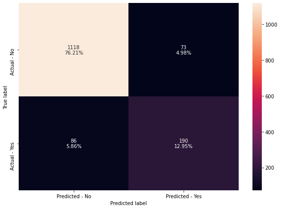

```python
d_tree = DecisionTreeClassifier(random_state=1)
d_tree.fit(X_train,y_train)

#Calculating different metrics
get_metrics_score(d_tree)

#Creating confusion matrix
make_confusion_matrix(d_tree,y_test)
```

### Tuning Decision Tree

```python
#Choose the type of classifier.
dtree_estimator = DecisionTreeClassifier(class_weight={0:0.18,1:0.72},random_state=1)

# Grid of parameters to choose from
parameters = {'max_depth': np.arange(2,30),
              'min_samples_leaf': [1, 2, 5, 7, 10],
              'max_leaf_nodes' : [2, 3, 5, 10,15],
              'min_impurity_decrease': [0.0001,0.001,0.01,0.1]
             }

# Type of scoring used to compare parameter combinations
scorer = metrics.make_scorer(metrics.recall_score)

# Run the grid search
grid_obj = GridSearchCV(dtree_estimator, parameters, scoring=scorer,n_jobs=-1)
grid_obj = grid_obj.fit(X_train, y_train)

# Set the clf to the best combination of parameters
dtree_estimator = grid_obj.best_estimator_

# Fit the best algorithm to the data.
dtree_estimator.fit(X_train, y_train)
```

```
DecisionTreeClassifier(class_weight={0: 0.18, 1: 0.72}, max_depth=5,
                       max_leaf_nodes=15, min_impurity_decrease=0.0001,
                       random_state=1)
```

```
Accuracy on training set :  0.7863197895352236
Accuracy on test set :  0.7934560327198364
Recall on training set :  0.6630434782608695
Recall on test set :  0.6811594202898551
Precision on training set :  0.4537725823591923
Precision on test set :  0.4665012406947891
```

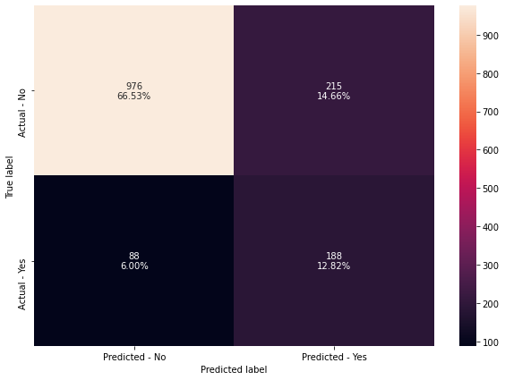

```python
get_metrics_score(dtree_estimator)

make_confusion_matrix(dtree_estimator,y_test)
```

Observations:

1. The decision tree model did overfit the data as seen from the huge discrepency in the test and train data.
2. There appears to be no overfitting on the Tuning Decision tree model as the train and test data are similar.
3. There appears to be no change in the recall score from either of the two models at 68%.

### Bagging Classifier

```
Accuracy on training set :  0.994153756211634
Accuracy on test set :  0.9161554192229039
Recall on training set :  0.9720496894409938
Recall on test set :  0.6268115942028986
Precision on training set :  0.9968152866242038
Precision on test set :  0.8963730569948186
```

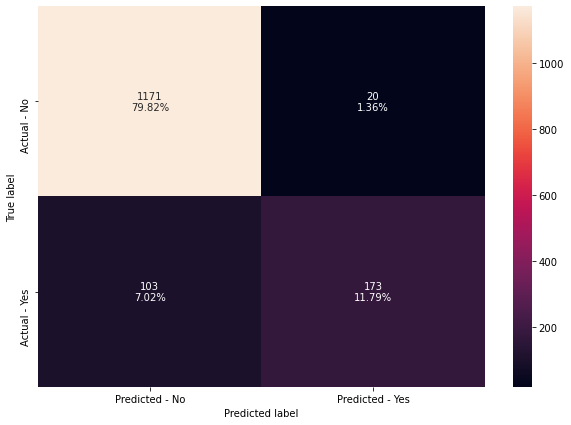

```python
bagging_estimator=BaggingClassifier(random_state=1)
bagging_estimator.fit(X_train,y_train)
#Using above defined function to get accuracy, recall and precision on train and test set
bagging_estimator_score=get_metrics_score(bagging_estimator)
make_confusion_matrix(bagging_estimator,y_test)
```

### Hypertuning Bagging Classifier

```python
# Choose the type of classifier.
bagging_estimator_tuned = BaggingClassifier(random_state=1)

# Grid of parameters to choose from
parameters = {'max_samples': [0.7,0.8,0.9,1],
              'max_features': [0.7,0.8,0.9,1],
              'n_estimators' : [10,20,30,40,50],
             }

# Type of scoring used to compare parameter combinations
scorer = metrics.make_scorer(metrics.recall_score)

# Run the grid search
grid_obj = GridSearchCV(bagging_estimator_tuned, parameters, scoring=scorer,cv=5)
grid_obj = grid_obj.fit(X_train, y_train)

# Set the clf to the best combination of parameters
bagging_estimator_tuned = grid_obj.best_estimator_

# Fit the best algorithm to the data.
bagging_estimator_tuned.fit(X_train, y_train)
```

```
BaggingClassifier(max_features=0.9, max_samples=0.9, n_estimators=50,
                  random_state=1)
```

```
Accuracy on training set :  0.9994153756211634
Accuracy on test set :  0.9284253578732107
Recall on training set :  0.9968944099378882
Recall on test set :  0.6630434782608695
Precision on training set :  1.0
Precision on test set :  0.9384615384615385
```

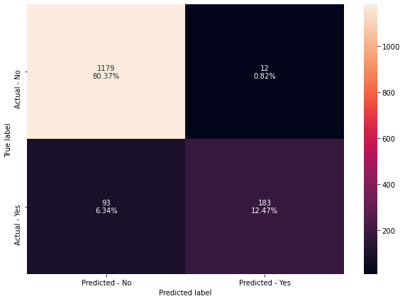

```python
#Calculating different metrics
get_metrics_score(bagging_estimator_tuned)

#Creating confusion matrix
make_confusion_matrix(bagging_estimator_tuned,y_test)
```

Observations: